# Data Processing for Low Carb High Fat Diet

Repeated measures on subjects

Mark Connolly

2016-10-17

# Introduction

Analysis of collected observations. Weaving executed code with explanatory text to produce literate programming (Knuth 1984) is provided by the R packages `knitr` (Xie 2016) and the document template `tufte` (Xie and Allaire 2016).

Knuth, Donald Ervin. 1984. “Literate Programming.” *The Computer Journal* 27 (2): 97–111.

Xie, Yihui. 2016. *Knitr: A General-Purpose Package for Dynamic Report Generation in R*. https://CRAN.R-project.org/package=knitr.

Xie, Yihui, and JJ Allaire. 2016. *Tufte: Tufte’s Styles for R Markdown Documents*. https://CRAN.R-project.org/package=tufte.

This document is translated from rmarkdown (Allaire et al. 2016) source. The source can be found at [LCHF Analysis.Rmd](https://github.com/markconnolly/lchf/blob/master/LCHF%20Analysis.Rmd).

Allaire, JJ, Joe Cheng, Yihui Xie, Jonathan McPherson, Winston Chang, Jeff Allen, Hadley Wickham, Aron Atkins, and Rob Hyndman. 2016. *Rmarkdown: Dynamic Documents for R*. http://rmarkdown.rstudio.com.

The `%>%` operator will be seen in some of the code. The package `magrittr` (Bache and Wickham 2014) provides this operator, called a pipe, which forwards the result of a preceeding function to a suceeding function in a sinle code stream. By default, the forwarded object is “piped” into the succeeding function’s first parameter slot. The argument can be moved to other parameter slots in the succeeding call Using the `.` placeholder. The pipe is used where it improves readability. A series of functions interspersed with `%>%` should be viewed as pipeline or processing elements, with the output of one function the input to the next.

Bache, Stefan Milton, and Hadley Wickham. 2014. *Magrittr: A Forward-Pipe Operator for R*. https://CRAN.R-project.org/package=magrittr.

R uses formulae to define response models. A formula is the form

`response variable ~ explanatory variables`

The structure of formulae is well-explained by (“R Tutorials–Model Formulae” 2016).

“R Tutorials–Model Formulae.” 2016. https://ww2.coastal.edu/kingw/statistics/R-tutorials/formulae.html. Accessed September 10.

# Crossover

At the start of the test, fat will predominate as the source of calories. As the test proceeds and the energy burn rate increases (as indicated by increased heartrate), fat as a source will diminish and carbohydrate as a source will increase. The crossover graph captures the trends and imputes the heartrate where fat and carbohydrate contribution are equal (the point where carbohydrate will start to become the predominant energy source).

## Data preparation for crossover

Set up for combining several spreadsheets into a single data frame. The sheets must all have the same naming convention, the same sheet structure, and the same column names.

```r
# a filter to be used to tell the Windows operating system to limit
# file selection to files that look like Excel
excelfilter <- matrix(c("Excel", "*.xls*"), ncol=2)

# a function that is used to ingest a conventionally named
# and structured spreadsheet and convert the file to a
# data frame (which is returned to the caller)
ingestvo2 <- function(afilename) {
  nameparts <- afilename %>% basename() %>% strsplit("[.]") %>% unlist()
  columnsfromfilename <-
    data.frame("subj" = as.character(nameparts[1]),
               "testnumber" = as.character(nameparts[2]),
               "testdate" = as.Date(nameparts[3],format="%m%d%y")
              )
  sheet <- # read the data
    read_excel(afilename,
               sheet=1,
               skip=4,
               col_names=FALSE)

  names(sheet) <- # read the column names
    trim(names(read_excel(afilename,
                          sheet=1,
                          skip=2,
                          col_names=TRUE)))

  return(cbind(columnsfromfilename,sheet))
}
```

## manual preparation

The collection software includes summary statistics at the sheet end of the sheet. If present, these rows are deleted.

## Select and combine Excel source files

Create a list that contains user-selected files, with each file processed by the `ingestvo2` function. The data frames in the list are then bound together by row. This is achieved in code using a pipeline of functions to process the inputs before assigning to the target variable. Note the `%>%` operator.

```r
excelfilter <- matrix(c("Excel", "*.xls*"), ncol=2)

vo2data <-
  choose.files(filters = excelfilter,
               caption = "Select VO2 files to combine") %>%
  lapply(FUN=ingestvo2) %>%
  do.call('rbind', .)

vo2data$subj = as.factor(vo2data$subj)
```

## Subset the test subject and test number

```r
fuel <-
  vo2data[,c("testnumber","subj","%Fat","%Carbs","HR")]
knitr::kable(head(fuel))
```

| testnumber | subj | %Fat | %Carbs | HR |
| --- | --- | --- | --- | --- |
| test0 | 258996 | 100.0 | 0.0 | 71 |
| test0 | 258996 | 60.2 | 39.8 | 17 |
| test0 | 258996 | 86.6 | 13.4 | 87 |
| test0 | 258996 | 87.8 | 12.2 | 85 |
| test0 | 258996 | 88.6 | 11.4 | 83 |
| test0 | 258996 | 91.2 | 8.8 | 83 |

## Restructure the data frame

Using the `gather` (Wickham 2016) function, create a “long” form of the data to be used for the plot. The `gather` function combines two or more columns such that the column names become factor values in a new column (the key colum) and the values of the designated columns become values in a second new column (the value column). The columns from the source not involved in the gathering remain in place, with values duplicated as needed to fill out the long structure. Functions `head` is used to convey the structure changes to the data frame, which can be compared to `head(fuel)` from above. The new structure makes “%Fat” and “%Carbs” factors and their values collapsed into a single variable.

Wickham, Hadley. 2016. *Tidyr: Easily Tidy Data with ‘Spread()‘ and ‘Gather()‘ Functions*. https://CRAN.R-project.org/package=tidyr.

```r
fuel_long <- gather(fuel,                # source data frame
                    percentage,          # new column name of the key
                    pctKcalmin,          # new column name of the value
                    c(`%Fat`,`%Carbs`))  # columns that are sources of
                                         # key names and values.
knitr::kable(head(fuel_long))   # shows the top part of the data frame
```

| testnumber | subj | HR | percentage | pctKcalmin |
| --- | --- | --- | --- | --- |
| test0 | 258996 | 71 | %Fat | 100.0 |
| test0 | 258996 | 17 | %Fat | 60.2 |
| test0 | 258996 | 87 | %Fat | 86.6 |
| test0 | 258996 | 85 | %Fat | 87.8 |
| test0 | 258996 | 83 | %Fat | 88.6 |
| test0 | 258996 | 83 | %Fat | 91.2 |

## Predicted calorie source ratio by heartrate

The percent contribution of fat and carbohydrates are plotted against heartrate. Plots are faceted by test number and subject to show individual responses across tests. The plots are created using `ggplot2` (Wickham and Chang 2016).

Wickham, Hadley, and Winston Chang. 2016. *Ggplot2: An Implementation of the Grammar of Graphics*. https://CRAN.R-project.org/package=ggplot2.

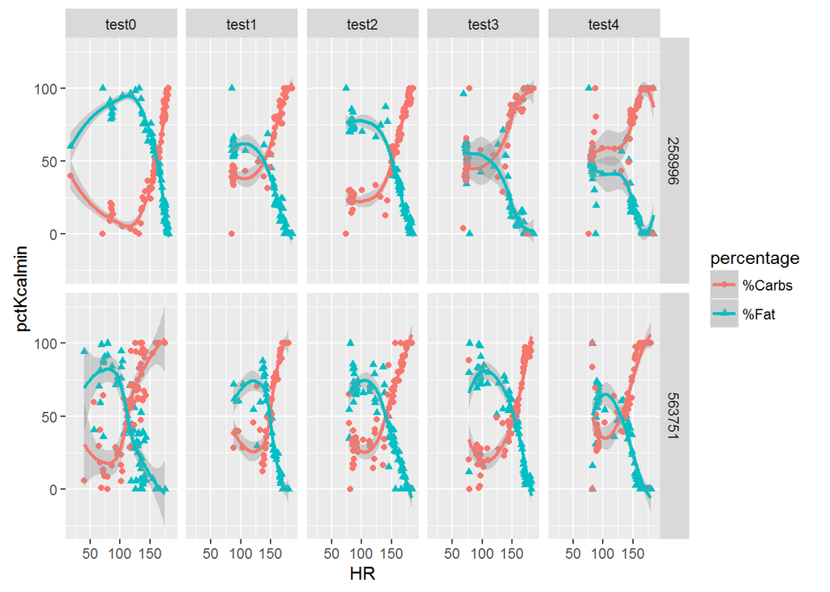

```r
ggplot(data=fuel_long,
       aes(x=HR, y=pctKcalmin,
           color=percentage,
           shape=percentage)) +
  geom_point() +
  geom_smooth(method="loess") +
  facet_grid(subj ~ testnumber)
```

## Predicted heartrate based on calorie source with predicted crossover

Using data manipulation functions from `dplyr` (Wickham and Francois 2016), the observations are used to build prediction models for each calorie source for each subject for each test. The prediction models are used to predict the heartrate when calorie sources are equal (both fat and carbohydrates are at 50%). The resulting data frame is used to mark and label the plots at the predicted heartrate.

Wickham, Hadley, and Romain Francois. 2016. *Dplyr: A Grammar of Data Manipulation*. https://CRAN.R-project.org/package=dplyr.

```r
crossoverHR50 <- group_by(fuel_long, testnumber, subj, percentage) %>%
                 do(HR = round(predict(loess(HR ~ pctKcalmin, data = .), newdata=50))) %>%
                 unnest() %>%
                 as.data.frame()

knitr::kable(crossoverHR50,
             caption = "Predicted heartrate at crossover")
```

Predicted heartrate at crossover

| testnumber | subj | percentage | HR |
| --- | --- | --- | --- |
| test0 | 258996 | %Carbs | 157 |
| test0 | 258996 | %Fat | 157 |
| test0 | 563751 | %Carbs | 112 |
| test0 | 563751 | %Fat | 112 |
| test1 | 258996 | %Carbs | 112 |
| test1 | 258996 | %Fat | 112 |
| test1 | 563751 | %Carbs | 134 |
| test1 | 563751 | %Fat | 132 |
| test2 | 258996 | %Carbs | 143 |
| test2 | 258996 | %Fat | 143 |
| test2 | 563751 | %Carbs | 122 |
| test2 | 563751 | %Fat | 122 |
| test3 | 258996 | %Carbs | 88 |
| test3 | 258996 | %Fat | 88 |
| test3 | 563751 | %Carbs | 151 |
| test3 | 563751 | %Fat | 151 |
| test4 | 258996 | %Carbs | 93 |
| test4 | 258996 | %Fat | 93 |
| test4 | 563751 | %Carbs | 121 |
| test4 | 563751 | %Fat | 121 |

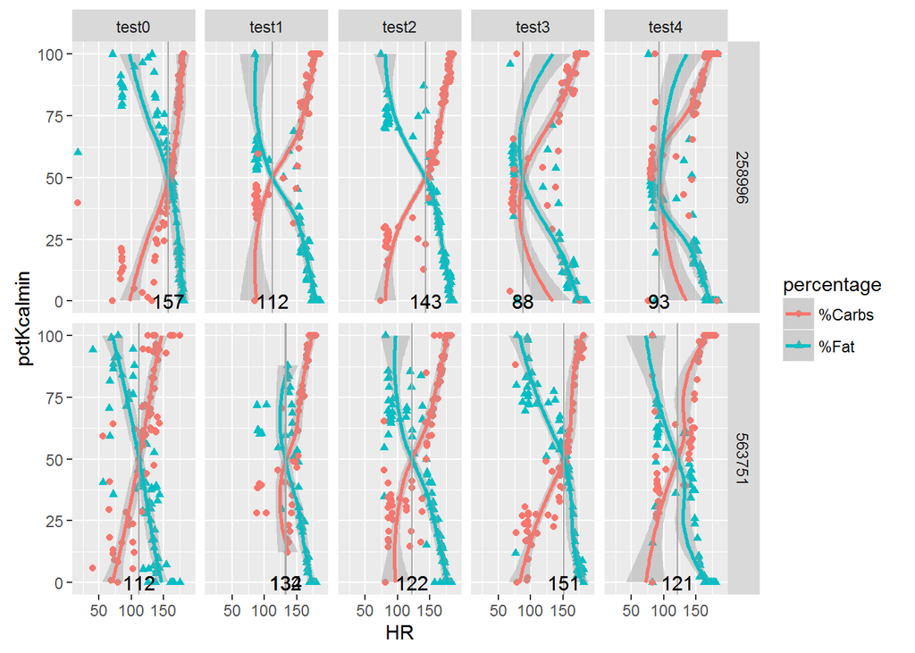

```r
ggplot(data=fuel_long,
       aes(x=pctKcalmin,
           y=HR,
           color=percentage,
           shape=percentage)) +
  geom_point() +
  geom_smooth() +
  facet_grid(subj ~ testnumber) +
  geom_hline(data = crossoverHR50, aes(yintercept = HR), colour="darkgrey") +
  geom_text(data = crossoverHR50, aes(label=HR, x=0, y=HR), colour="black") +
  coord_flip()
```

# Heartrate at RER 0.5

Working model for analysis: (Gribble 2009)

Gribble, Paul. 2009. “Repeated Measures ANOVA Using R.” *Motor Control Lab Blog*. https://gribblelab.wordpress.com/2009/03/09/repeated-measures-anova-using-r/.

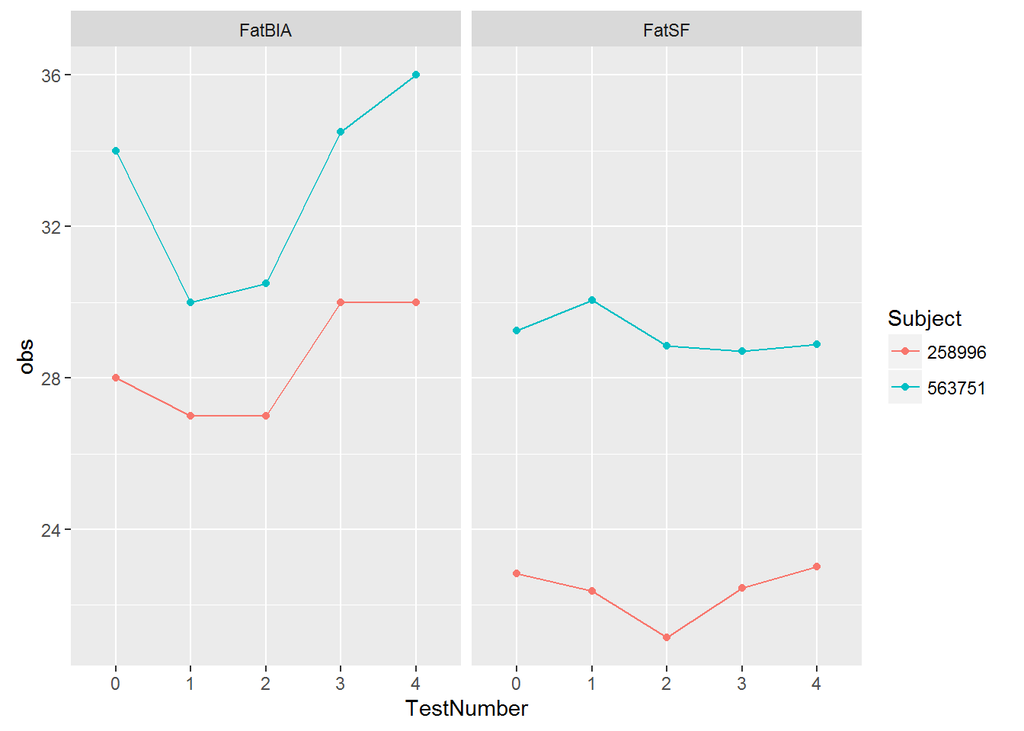

```r
excelfilter <- matrix(c("Excel", "*.xls*"), ncol=2)

rer <- choose.files(filters = excelfilter,
                    caption = "Select rer file",
                    multi=FALSE) %>%
       read_excel(sheet=1)

# make the names more convenient to use
names(rer) <- gsub(" ", "", names(rer), fixed=TRUE)
names(rer) <- gsub("(", "_", names(rer), fixed=TRUE)
names(rer) <- gsub(")", "", names(rer), fixed=TRUE)
names(rer) <- gsub("%", "pct", names(rer), fixed=TRUE)

# convert factors to factors
rer$Subject <- as.factor(rer$Subject)
rer$TestNumber <- as.factor(rer$TestNumber)

rer2 <- rer[c("Subject","TestNumber",
              "RERHR",
              "MaxRelVO2","MaxAbsVO2",
              "BFpctBIA","SFBFpct",
              "MoodB4_cm","MoodAfter_cm",
              "FatBIA","FatSF")]

rer2_long <-
  rer[c("Subject","TestNumber",
        "RERHR",
        "MaxRelVO2","MaxAbsVO2",
        "BFpctBIA","SFBFpct",
        "MoodB4_cm","MoodAfter_cm",
        "FatBIA","FatSF")]            %>%
  gather(measurement,obs,RERHR:FatSF)

rer2_long$measurement <-
  ordered(rer2_long$measurement,
          levels = c("RERHR",
                     "MaxRelVO2","MaxAbsVO2",
                     "BFpctBIA","SFBFpct",
                     "MoodB4_cm","MoodAfter_cm",
                     "FatBIA","FatSF"))

scales <- "fixed";columns <- c("RERHR")
scales <- "free";columns <- c("MaxRelVO2","MaxAbsVO2")
scales <- "fixed";columns <- c("BFpctBIA","SFBFpct")
scales <- "fixed";columns <- c("MoodB4_cm","MoodAfter_cm")
scales <- "fixed";columns <- c("FatBIA","FatSF")

rer2_long %>%
  subset(measurement %in% columns) %>%
  ggplot(data=., aes(x=TestNumber,
                     y=obs,
                     color=Subject,
                     group = Subject)) +
  geom_point() +
  geom_line() +
  facet_wrap(~measurement, scales = scales)
```

```r
summary(aov(RERHR ~ Error(Subject), data=rer))
```

```
##
## Error: Subject
##           Df Sum Sq Mean Sq F value Pr(>F)
## Residuals  1   44.1    44.1
##
## Error: Within
##           Df Sum Sq Mean Sq F value Pr(>F)
## Residuals  8  514.8   64.35
```